# Chapter 2: Seminar - ARMA Models Exercises

```python
# Ljung-Box test
print("\nLjung-Box Test:")
lb = acorr_ljungbox(resid.dropna(), lags=[10, 15, 20], return_df=True)
print(lb)
```

```
Ljung-Box Test:
      lb_stat  lb_pvalue
10   7.418163   0.685465
15   8.737943   0.890816
20  15.916668   0.721780
```

```
6. FORECASTING AND EVALUATION
```

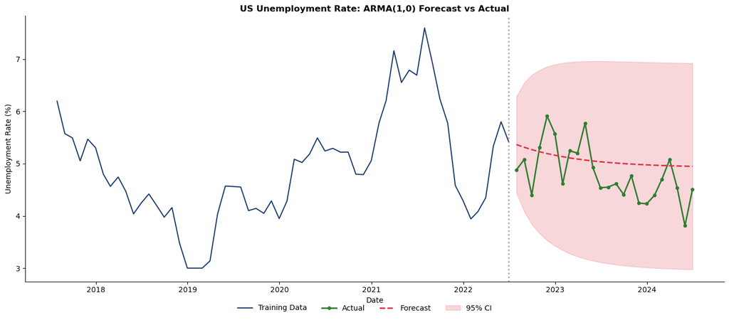

```python
# Step 6: Forecasting and evaluation
print("\n6. FORECASTING AND EVALUATION")

# Generate forecasts for the test period
forecast = final_fit.get_forecast(steps=len(test))
forecast_mean = forecast.predicted_mean
conf_int = forecast.conf_int()

# Plot: Training data (last 60 obs) + Forecast vs Actual
fig, ax = plt.subplots(figsize=(14, 6))

# Training data (last 60 observations)
ax.plot(train.index[-60:], train.values[-60:], color=BLUE, linewidth=1.5, label='Training Data')

# Actual test data
ax.plot(test.index, test.values, color=GREEN, linewidth=2, label='Actual', marker='o', markersize=4)

# Forecast
ax.plot(test.index, forecast_mean.values, color=RED, linewidth=2, linestyle='--', label='Forecast')

# Confidence interval
ax.fill_between(test.index, conf_int.iloc[:, 0].values, conf_int.iloc[:, 1].values,
                color=RED, alpha=0.2, label='95% CI')

# Vertical line separating train/test
ax.axvline(x=train.index[-1], color='gray', linestyle=':', alpha=0.7, linewidth=2)

ax.set_title(f'US Unemployment Rate: ARMA({best_p},{best_q}) Forecast vs Actual', fontweight='bold')
ax.set_xlabel('Date')
ax.set_ylabel('Unemployment Rate (%)')

handles, labels = ax.get_legend_handles_labels()
fig.legend(handles, labels, loc='lower center', ncol=4, bbox_to_anchor=(0.5, -0.02))
plt.subplots_adjust(bottom=0.15)
plt.tight_layout()
plt.show()
```

```python
# Forecast accuracy metrics
from sklearn.metrics import mean_absolute_error, mean_squared_error

mae = mean_absolute_error(test, forecast_mean)
rmse = np.sqrt(mean_squared_error(test, forecast_mean))
mape = np.mean(np.abs((test - forecast_mean) / test)) * 100

print("\nForecast Accuracy Metrics (24-month horizon):")
print(f"  Mean Absolute Error (MAE): {mae:.3f} percentage points")
print(f"  Root Mean Squared Error (RMSE): {rmse:.3f} percentage points")
print(f"  Mean Absolute Percentage Error (MAPE): {mape:.2f}%")

# Multi-step forecast visualization
print("\n" + "="*60)
print("Forecast Detail (first 12 months):")
print("-"*60)
forecast_df = pd.DataFrame({
    'Date': test.index[:12],
    'Actual': test.values[:12],
    'Forecast': forecast_mean.values[:12],
    'Error': (test.values[:12] - forecast_mean.values[:12])
})
forecast_df['Date'] = forecast_df['Date'].dt.strftime('%Y-%m')
print(forecast_df.to_string(index=False))

print("\nKey Insights:")
print("- Forecasts show dynamic adjustment based on AR/MA structure")
print("- Unlike stock returns, unemployment has strong predictable patterns")
print("- Long-horizon forecasts converge to the unconditional mean (mean reversion)")
```

```
Forecast Accuracy Metrics (24-month horizon):
  Mean Absolute Error (MAE): 0.459 percentage points
  Root Mean Squared Error (RMSE): 0.531 percentage points
  Mean Absolute Percentage Error (MAPE): 9.96%

============================================================
Forecast Detail (first 12 months):
------------------------------------------------------------
   Date   Actual  Forecast     Error
2022-07 4.879503  5.364139 -0.484636
2022-08 5.079625  5.312840 -0.233215
2022-09 4.400681  5.267487 -0.866806
2022-10 5.307418  5.227390  0.080028
2022-11 5.911191  5.191941  0.719250
2022-12 5.572899  5.160600  0.412299
2023-01 4.613870  5.132891 -0.519021
2023-02 5.247072  5.108395  0.138677
2023-03 5.199467  5.086737  0.112730
2023-04 5.774758  5.067589  0.707169
2023-05 4.925893  5.050661 -0.124768
2023-06 4.539113  5.035695 -0.496582

Key Insights:
- Forecasts show dynamic adjustment based on AR/MA structure
- Unlike stock returns, unemployment has strong predictable patterns
- Long-horizon forecasts converge to the unconditional mean (mean reversion)
```

### Discussion 1

**Scenario:** You fit an ARMA(2,1) model to a financial return series. The estimated parameters are:

- $\hat{\phi}_1 = 0.3$, $\hat{\phi}_2 = 0.4$, $\hat{\theta}_1 = -0.2$

The Ljung-Box test on residuals gives p-value = 0.08.

**Questions:**

1. Check if the AR part is stationary (hint: check if $\phi_1 + \phi_2 < 1$ and $\phi_2 - \phi_1 < 1$ and $|\phi_2| < 1$).
2. Is the MA part invertible?
3. Based on the Ljung-Box test, is the model adequate at the 5% significance level?

**Your Answer:**

### Discussion 2

**Scenario:** Your colleague says: "I always use AIC to select models because it gives me better forecasts. BIC is too conservative."

**Questions:**

1. What is the key difference between AIC and BIC in terms of the penalty term?
2. Under what conditions might BIC be preferred over AIC?
3. Is your colleague's statement always correct? Why or why not?

**Your Answer:**

# Summary

## Key Takeaways from Today's Seminar

1. **Lag Operator** - $(1-L)X_t = X_t - X_{t-1}$ (first difference)
2. **Stationarity & Invertibility**:
   - AR stationarity: roots of $\phi(z)=0$ outside unit circle
   - MA invertibility: roots of $\theta(z)=0$ outside unit circle
3. **Model Identification**:
   - AR(p): ACF decays, PACF cuts off at lag p
   - MA(q): ACF cuts off at lag q, PACF decays
   - ARMA: Both decay
4. **Model Selection**:
   - AIC = -2log(L) + 2k (better for prediction)
   - BIC = -2log(L) + k*log(n) (better for true model)
5. **Diagnostics**:
   - Ljung-Box test: H0 = residuals are white noise
   - Check ACF of residuals (should be within confidence bands)
   - Q-Q plot for normality
6. **Forecasting**:
   - Stationary ARMA forecasts revert to unconditional mean
   - Confidence intervals widen with horizon

## Next Seminar

ARIMA models, seasonal ARIMA (SARIMA), and advanced forecasting techniques